# Assignment 4

```r
NA
```

Step 2: Transform response time (lineuprt) to correct for the skew

```r
lineuprt_log <- (log10(traindata$lineuprt))
```

Step 3: Investigate distribution for log10 transformation of response time (lineuprt_log)

```r
describe(lineuprt_log)
```

|  | vars | n | mean | sd | median | trimmed | mad | min | max | range | skew | kurtosis | se |
| --- | --- | --- | --- | --- | --- | --- | --- | --- | --- | --- | --- | --- | --- |
| X1 | 1 | 117 | 4.35 | 0.28 | 4.32 | 4.34 | 0.28 | 3.7 | 5.09 | 1.39 | 0.39 | 0.06 | 0.03 |

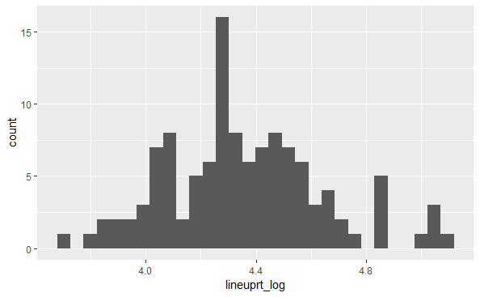

```r
ggplot(data = traindata, mapping = aes(x = lineuprt_log))+
  geom_histogram()
```

Table 1 indicates that the unacceptable levels of skewness and kurtosis have been resolved with a log10 transformation. Graph 1 confirms this, although it appears there are still some outliers. ____________________________________________________________________________ Step 4: Test whether 1)confidence of response (confidence) is predictive of lineup accuracy (lineupacc), and 2)the transformed lineup response time (lineuprt_log) is predictive of eyewitness accuracy(lineupacc). These relationships will then each be faceted by target presence (lineuptpta), and length of initail exposure to target (exposure), to investigate whether these factors influence the abovementioned relationships.

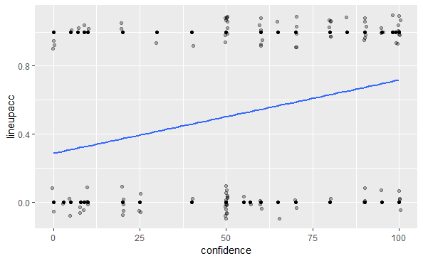

```r
ggplot(traindata, aes(x = confidence, y = lineupacc))+
  geom_point()+
    geom_jitter(height = .1, alpha = 0.3)+
    geom_smooth(method = "glm",
                se = F)
```

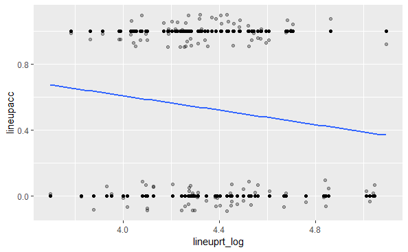

```r
ggplot(traindata, aes(x = lineuprt_log, y = lineupacc))+
  geom_point()+
    geom_jitter(height = .1, alpha = 0.3)+
    geom_smooth(method = "glm",
                se = F)
```

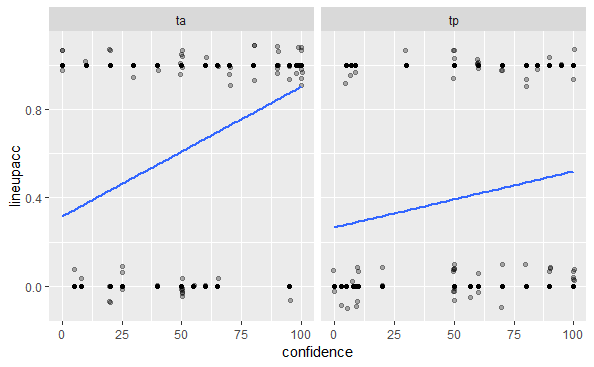

```r
ggplot(traindata, aes(x = confidence, y = lineupacc))+
  geom_point()+
    geom_jitter(height = .1, alpha = 0.3)+
    geom_smooth(method = "glm",
                se = F)+
  facet_wrap(~lineuptpta)
```

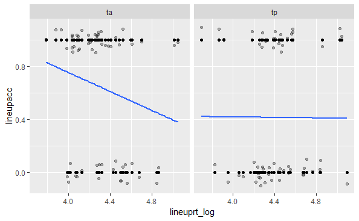

```r
ggplot(traindata, aes(x = lineuprt_log, y = lineupacc))+
  geom_point()+
    geom_jitter(height = .1, alpha = 0.3)+
    geom_smooth(method = "glm",
                se = F)+
facet_wrap(~lineuptpta)
```

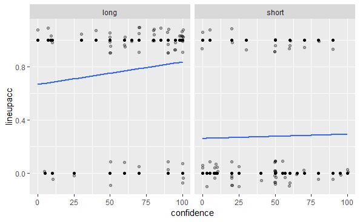

```r
ggplot(traindata, aes(x = confidence, y = lineupacc))+
  geom_point()+
    geom_jitter(height = .1, alpha = 0.3)+
    geom_smooth(method = "glm",
                se = F)+
  facet_wrap(~exposure)
```

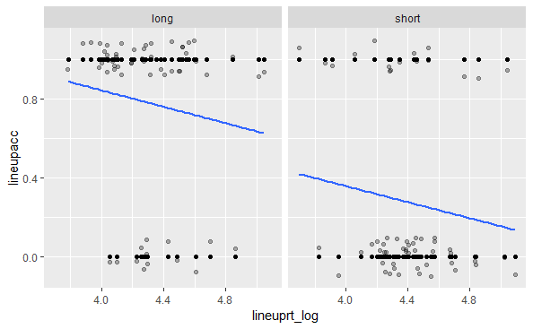

```r
ggplot(traindata, aes(x = lineuprt_log, y = lineupacc))+
  geom_point()+
    geom_jitter(height = .1, alpha = 0.3)+
    geom_smooth(method = "glm",
                se = F)+
  facet_wrap(~exposure)
```

Graph 1 suggests that the more confident a participant is in their response overall, the more likely it is that they have given a correct reponse. Graph 2 sugests that the longer it takes a participant to give a response overall, the less likely it is that they have given a correct response.

Graph 3 suggests that the effect of confidence on accuracy is much stronger in target absence lineups than in target present lineups Graph 4 suggests that the length of response time affects lineup accuracy negatively only in target absent lineups. This effect is almost null in target present lineups.

Graph 5 suggests that the effect of confidence on accuracy is slightly stronger in the long video condition than in the short video condition (which is very weak) Graph 6 suggests that length of response time negatively affects lineup accuracy for both the long and short video conditions